# Rshiny

## Output Example - plotOutput

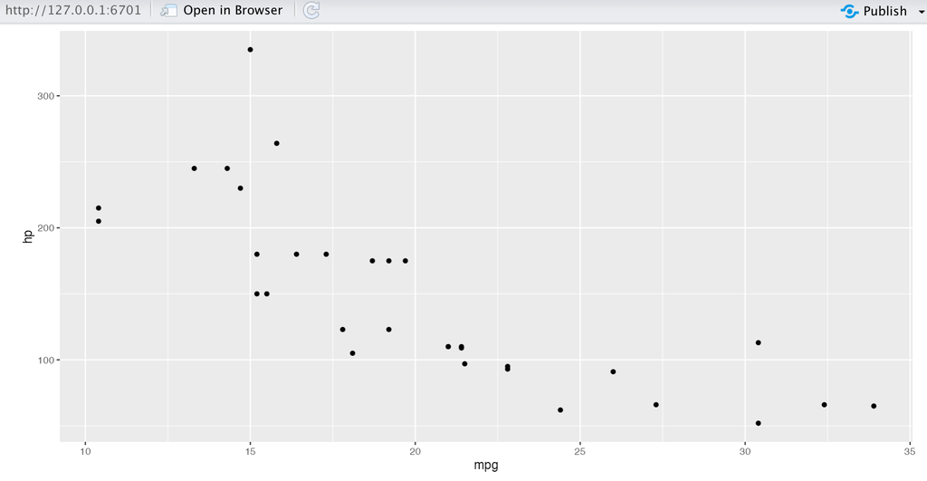

```r
ui <- fluidPage(
  plotOutput("plot")
)
server <- function(input, output, session) {
  output$plot <- renderPlot(
    ggplot(mtcars, x=mpg, y=hp) + geom_point()
  )
}
```

## Output and render functions will typically be used together

- Outputs will be in the UI and render functions in the server
- tableOutput() and renderTable()
- plotOutput() and renderPlot()
- textOutput() and renderText()

## Outputing the values contained within inputs

```r
# Function example
states <-c("Massachussets", "New York", "Maryland")
ui <- fluidPage(
  selectInput("state", "Choose your state", states),
  textOutput("selected")
)
server <- function(input, output, session) {
  output$selected <- renderText(input$state)
}
```

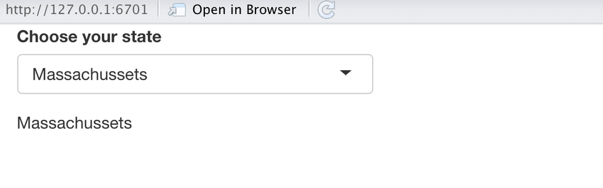

## HTML Layouts organize your inputs and outputs

## fluidPage Simple Layout - Code

```r
fluidPage(
  titlePanel(
    # app title/description
  ),
  sidebarLayout(
    sidebarPanel(
      # inputs
    ),
    mainPanel(
      # outputs
    )
  )
)
```

## Simple Layout View

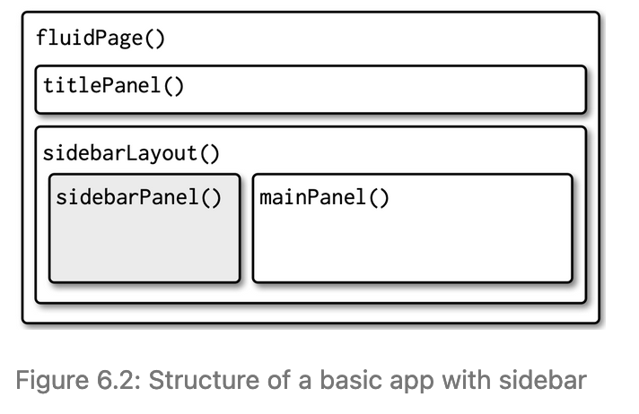

## Multirow layout code

```r
fluidPage(
  fluidRow(
    column(4,
      ...
    ),
    column(8,
      ...
    )
  ),
  fluidRow(
    column(6,
      ...
    ),
    column(6,
      ...
    )
  )
)
```

## Multirow Layout View

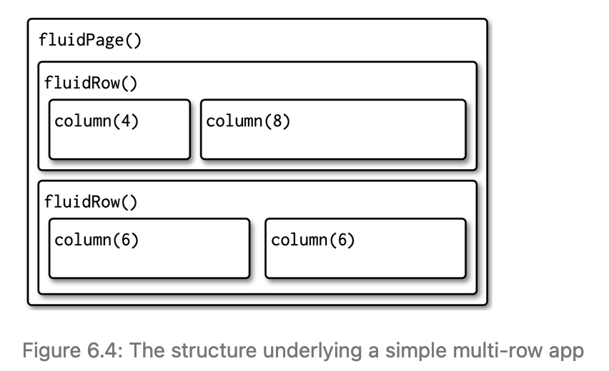

## Putting it all together

## Code - Basic Shiny App UI

```r
# Load libraries
library('shiny')
library('tidyverse')

# UI layout with a sidebar and mainpanel
# plotOutput contains the information from output$plot
ui <- fluidPage(
  titlePanel("mtcars Plot"),
  sidebarLayout(
    sidebarPanel("UI Elements could go here"
    ),
    mainPanel(
      plotOutput("plot")
    )
  )
)
```

## Code Basic Shiny App Server

```r
# renderPlot() creates the output sent to output$plot by calling ggplot
server <- function(input, output, session) {
  output$plot <- renderPlot(
    ggplot(mtcars, aes(x=mpg, y=hp)) + geom_point()
  )
}

shinyApp(ui = ui, server = server)
```

## View of basic Shiny App

[figure not shown]

## Reactivity

## Reactivity Principles

- Reactive expressions and outputs will only change *if and only if* their inputs change
- Laziness means code will only be re-run if needed
  - Shiny will handle figuring out the minimal amount of code that needs to be re-run based on what’s changed
- Reactivity can be used to control the flow of data and actions through your application
- https://mastering-shiny.org/basic-reactivity.html

## Reactive Expressions

- render* functions are reactive expressions
- You can create your own by wrapping your function with `reactive({})`
- Reactive expressions cache their results and only return a new result if it detects any changes in dependencies
- Render* + built-in input selections are a simple example of reactivity